# Daily R - October 2021

# 20211001 - trying [{aRtsy}](https://koenderks.github.io/aRtsy/)

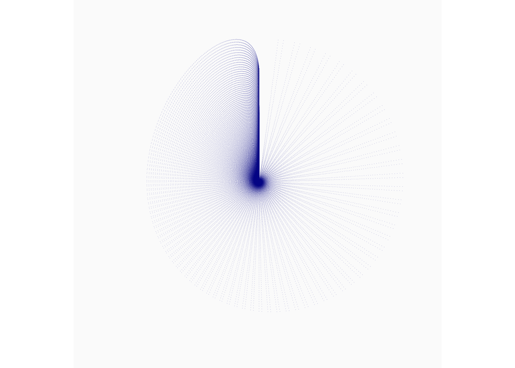

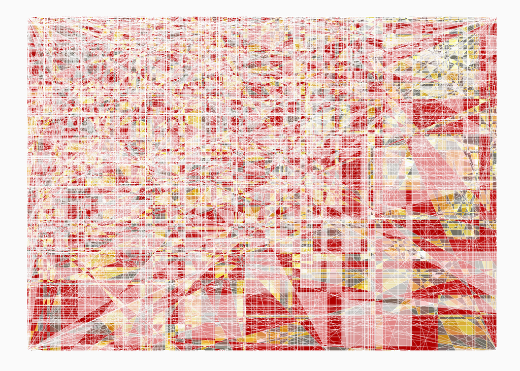

[figure not shown]

# 20211004 - [WIC Data](https://www.fns.usda.gov/pd/wic-program)

# 20211005 - #TidyTuesday and Registered Nurses

Data summary

| Name | nurses |
| --- | --- |
| Number of rows | 1242 |
| Number of columns | 22 |
| _______________________ |  |
| Column type frequency: |  |
| character | 1 |
| numeric | 21 |
| ________________________ |  |
| Group variables | None |

**Variable type: character**

| skim_variable | n_missing | complete_rate | min | max | empty | n_unique | whitespace |
| --- | --- | --- | --- | --- | --- | --- | --- |
| state | 0 | 1 | 4 | 20 | 0 | 54 | 0 |

**Variable type: numeric**

| skim_variable | n_missing | complete_rate | mean | sd | p0 | p25 | p50 | p75 | p100 | hist |
| --- | --- | --- | --- | --- | --- | --- | --- | --- | --- | --- |
| year | 0 | 1.00 | 2009.00 | 6.64 | 1998.00 | 2.00300e+03 | 2009.00 | 2015.00 | 2020.00 | ▇▆▇▆▇ |
| total_employed_rn | 5 | 1.00 | 47703.88 | 50241.05 | 240.00 | 1.22100e+04 | 31160.00 | 60230.00 | 307060.00 | ▇▂▁▁▁ |
| employed_standard_error_percent | 5 | 1.00 | 4.36 | 3.04 | 0.70 | 2.50000e+00 | 3.50 | 5.10 | 26.10 | ▇▂▁▁▁ |
| hourly_wage_avg | 6 | 1.00 | 28.48 | 6.65 | 9.23 | 2.37000e+01 | 28.25 | 32.39 | 57.96 | ▁▇▆▁▁ |
| hourly_wage_median | 6 | 1.00 | 27.86 | 6.72 | 8.64 | 2.30800e+01 | 27.58 | 31.72 | 56.93 | ▁▇▇▁▁ |
| annual_salary_avg | 6 | 1.00 | 59248.30 | 13829.14 | 19190.00 | 4.93000e+04 | 58750.00 | 67377.50 | 120560.00 | ▁▇▆▁▁ |
| annual_salary_median | 6 | 1.00 | 57957.92 | 13978.95 | 17970.00 | 4.79950e+04 | 57375.00 | 65987.50 | 118410.00 | ▁▇▇▁▁ |
| wage_salary_standard_error_percent | 6 | 1.00 | 1.27 | 0.70 | 0.40 | 9.00000e-01 | 1.10 | 1.42 | 7.50 | ▇▁▁▁▁ |
| hourly_10th_percentile | 6 | 1.00 | 20.23 | 4.66 | 6.38 | 1.68100e+01 | 20.04 | 23.54 | 36.62 | ▁▆▇▃▁ |
| hourly_25th_percentile | 6 | 1.00 | 23.54 | 5.51 | 7.33 | 1.94700e+01 | 23.24 | 27.01 | 45.18 | ▁▇▇▂▁ |
| hourly_75th_percentile | 6 | 1.00 | 32.92 | 8.07 | 10.04 | 2.72100e+01 | 32.61 | 37.33 | 71.07 | ▁▇▅▁▁ |
| hourly_90th_percentile | 6 | 1.00 | 38.16 | 9.23 | 12.33 | 3.25100e+01 | 37.50 | 43.41 | 83.35 | ▁▇▅▁▁ |
| annual_10th_percentile | 6 | 1.00 | 42087.70 | 9694.20 | 13260.00 | 3.49575e+04 | 41670.00 | 48955.00 | 76180.00 | ▁▆▇▃▁ |
| annual_25th_percentile | 6 | 1.00 | 48968.81 | 11469.49 | 15260.00 | 4.04875e+04 | 48335.00 | 56195.00 | 93970.00 | ▁▇▇▂▁ |
| annual_75th_percentile | 6 | 1.00 | 68464.53 | 16777.63 | 20890.00 | 5.65975e+04 | 67835.00 | 77637.50 | 147830.00 | ▁▇▅▁▁ |
| annual_90th_percentile | 6 | 1.00 | 79367.01 | 19201.21 | 25650.00 | 6.76200e+04 | 78015.00 | 90290.00 | 173370.00 | ▁▇▅▁▁ |
| location_quotient | 649 | 0.48 | 1.01 | 0.19 | 0.32 | 9.00000e-01 | 1.01 | 1.13 | 1.50 | ▁▁▇▇▁ |
| total_employed_national_aggregate | 4 | 1.00 | 134075563.81 | 6133532.52 | 124143490.00 | 1.29059e+08 | 131713800.00 | 138885360.00 | 147838700.00 | ▅▇▅▃▃ |
| total_employed_healthcare_national_aggregate | 4 | 1.00 | 7268640.12 | 943177.74 | 5854360.00 | 6.22654e+06 | 7250140.00 | 8076300.00 | 8727310.00 | ▇▃▅▅▆ |
| total_employed_healthcare_state_aggregate | 2 | 1.00 | 134743.23 | 143540.40 | 110.00 | 3.34475e+04 | 87435.00 | 175292.50 | 844930.00 | ▇▂▁▁▁ |
| yearly_total_employed_state_aggregate | 0 | 1.00 | 2387208.60 | 2774288.09 | 110.00 | 5.96520e+05 | 1557110.00 | 2888682.50 | 17382400.00 | ▇▂▁▁▁ |

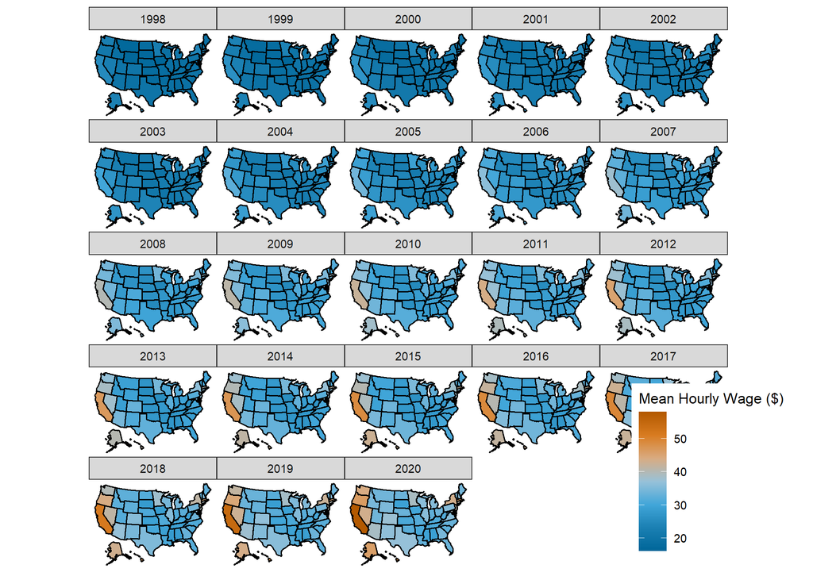

# 20211006 - Clean WIC data

# 20211007 - More Cleaning of the WIC Data

I need to figure out how to track their indentations.

I used `lag`, but I can’t figure out how to make the `n` dynamically change based on the number of tribes within each state.

Moving on, because I don’t feel passionate about this dataset.

# 20211008 - checking out [{groundhog}](https://groundhogr.com/)

{groundhog} lets you use packages based on a certain date. For example, if you ran your script on 2021-10-08 and you want the packages to be exactly the same (i.e. version number), you can use this package.

# 20211011 - trying [{tidymodels}](https://www.tidymodels.org/)

This week (except for Tuesday), I am going to work on the tidymodels framework.

Plot of raw data.

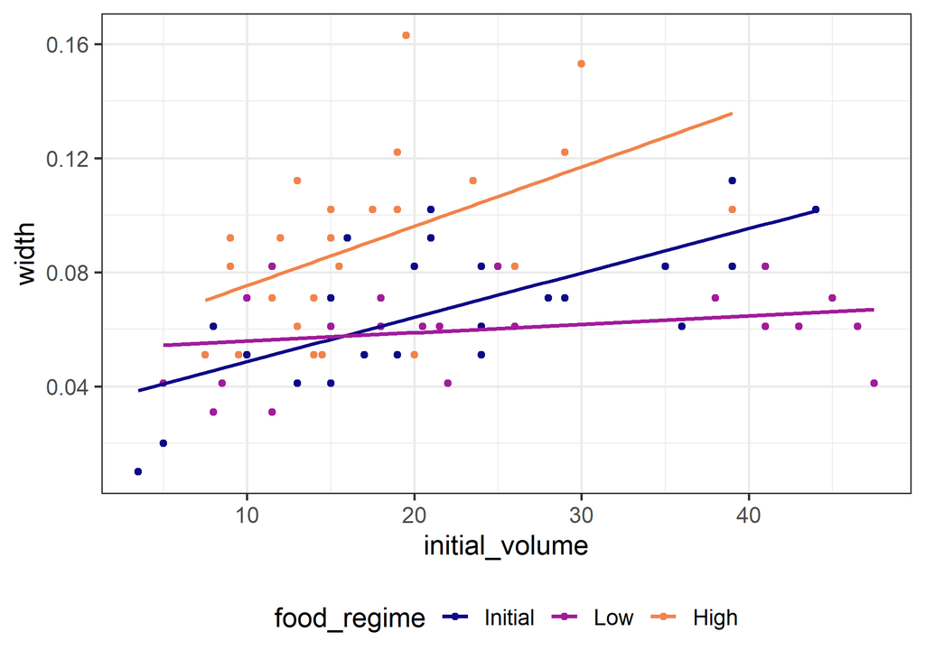

Model summary (table and dot-whisker plot).

```
## # A tibble: 6 x 5
##   term                            estimate std.error statistic  p.value
##   <chr>                              <dbl>     <dbl>     <dbl>    <dbl>
## 1 (Intercept)                     0.0331    0.00962      3.44  0.00100
## 2 initial_volume                  0.00155   0.000398     3.91  0.000222
## 3 food_regimeLow                  0.0198    0.0130       1.52  0.133
## 4 food_regimeHigh                 0.0214    0.0145       1.47  0.145
## 5 initial_volume:food_regimeLow  -0.00126   0.000510    -2.47  0.0162
## 6 initial_volume:food_regimeHigh  0.000525  0.000702     0.748 0.457
```

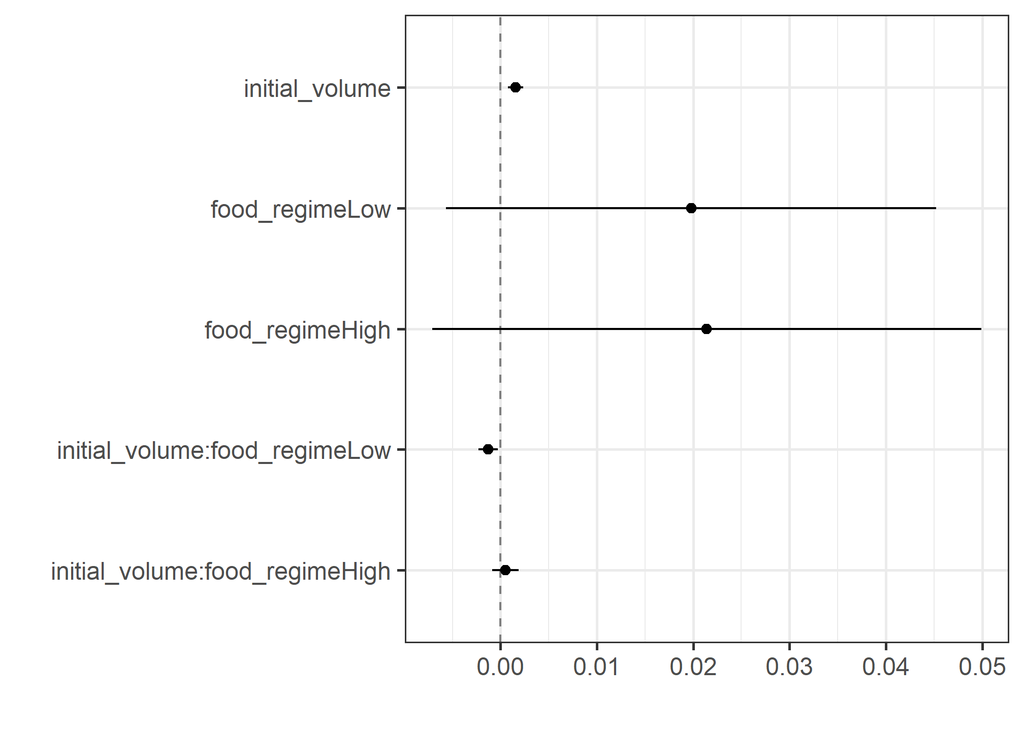

Predictions

Plot of predictions

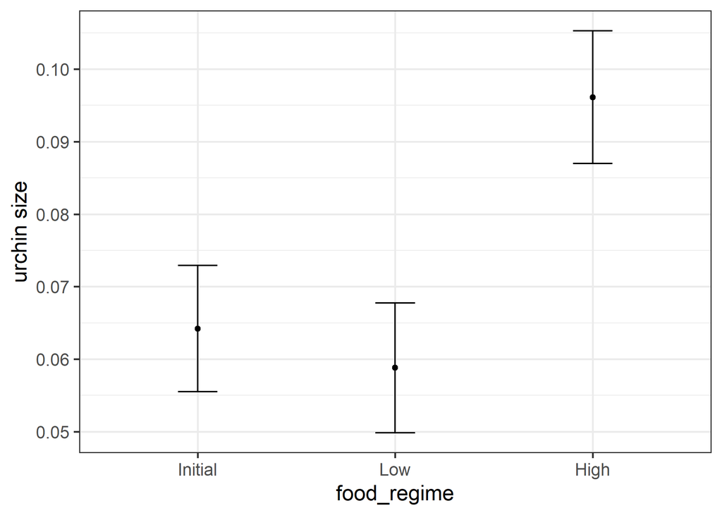

# 20211012 - #TidyTuesday and Seafood Production

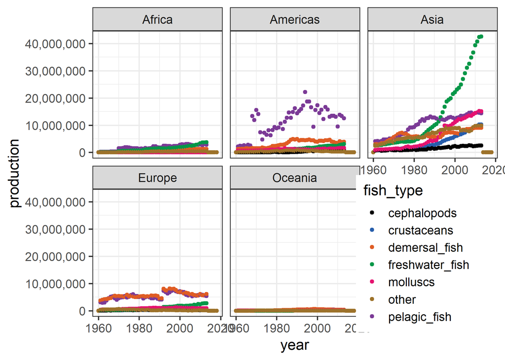

# 20211013 - More {tidymodels} - [{recipes}](https://www.tidymodels.org/start/recipes/)

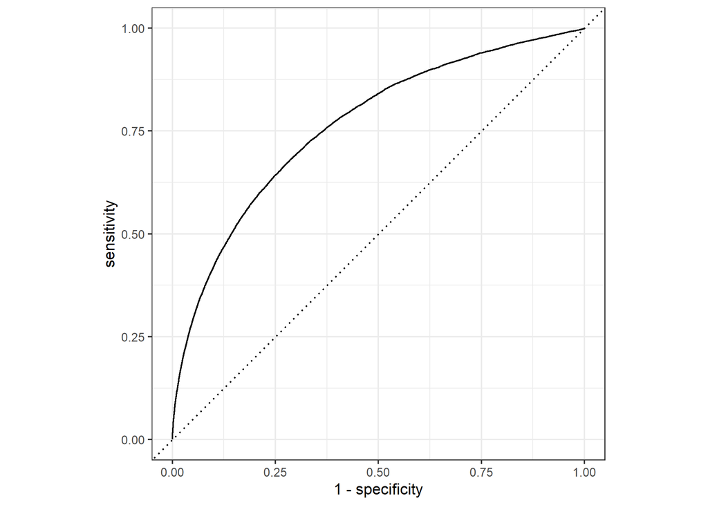

```
## # A tibble: 1 x 3
##   .metric .estimator .estimate
##   <chr>   <chr>          <dbl>
## 1 roc_auc binary         0.764
```

Not too bad! We leave it to the reader to test out this workflow without this recipe. You can use `workflows::add_formula(arr_delay ~ .)` instead of `add_recipe()` (remember to remove the identification variables first!), and see whether our recipe improved our model’s ability to predict late arrivals.

`remove_formula`

# 20211014 - More {tidymodels} - [{resampling}](https://www.tidymodels.org/start/resampling/)

```
## # A tibble: 1 x 3
##   .metric .estimator .estimate
##   <chr>   <chr>          <dbl>
## 1 roc_auc binary          1.00
```

```
## # A tibble: 1 x 3
##   .metric  .estimator .estimate
##   <chr>    <chr>          <dbl>
## 1 accuracy binary         0.990
```

```
## # A tibble: 1 x 3
##   .metric .estimator .estimate
##   <chr>   <chr>          <dbl>
## 1 roc_auc binary         0.891
```

```
## # A tibble: 1 x 3
##   .metric  .estimator .estimate
##   <chr>    <chr>          <dbl>
## 1 accuracy binary         0.814
```

```
## #  10-fold cross-validation
## # A tibble: 10 x 2
##    splits             id
##    <list>             <chr>
##  1 <split [1362/152]> Fold01
##  2 <split [1362/152]> Fold02
##  3 <split [1362/152]> Fold03
##  4 <split [1362/152]> Fold04
##  5 <split [1363/151]> Fold05
##  6 <split [1363/151]> Fold06
##  7 <split [1363/151]> Fold07
##  8 <split [1363/151]> Fold08
##  9 <split [1363/151]> Fold09
## 10 <split [1363/151]> Fold10
```

```
## # Resampling results
## # 10-fold cross-validation
## # A tibble: 10 x 4
##    splits             id     .metrics         .notes
##    <list>             <chr>  <list>           <list>
##  1 <split [1362/152]> Fold01 <tibble [2 x 4]> <tibble [0 x 1]>
##  2 <split [1362/152]> Fold02 <tibble [2 x 4]> <tibble [0 x 1]>
##  3 <split [1362/152]> Fold03 <tibble [2 x 4]> <tibble [0 x 1]>
##  4 <split [1362/152]> Fold04 <tibble [2 x 4]> <tibble [0 x 1]>
##  5 <split [1363/151]> Fold05 <tibble [2 x 4]> <tibble [0 x 1]>
##  6 <split [1363/151]> Fold06 <tibble [2 x 4]> <tibble [0 x 1]>
##  7 <split [1363/151]> Fold07 <tibble [2 x 4]> <tibble [0 x 1]>
##  8 <split [1363/151]> Fold08 <tibble [2 x 4]> <tibble [0 x 1]>
##  9 <split [1363/151]> Fold09 <tibble [2 x 4]> <tibble [0 x 1]>
## 10 <split [1363/151]> Fold10 <tibble [2 x 4]> <tibble [0 x 1]>
```

```
## # A tibble: 2 x 6
##   .metric  .estimator  mean     n std_err .config
##   <chr>    <chr>      <dbl> <int>   <dbl> <chr>
## 1 accuracy binary     0.833    10 0.00876 Preprocessor1_Model1
## 2 roc_auc  binary     0.905    10 0.00627 Preprocessor1_Model1
```

# 20211015 - More {tidymodels} - [{tuning}](https://www.tidymodels.org/start/tuning/)

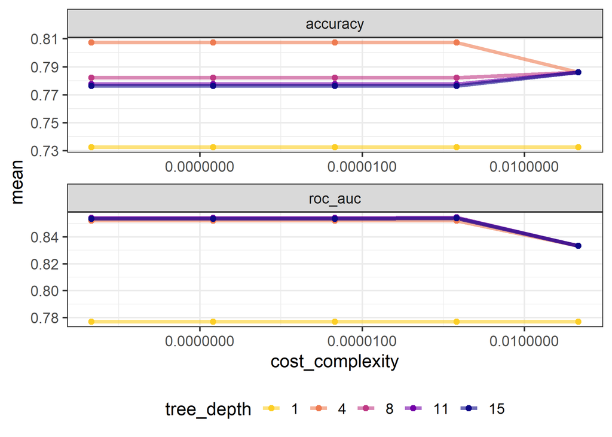

```
## # A tibble: 2 x 4
##   .metric  .estimator .estimate .config
##   <chr>    <chr>          <dbl> <chr>
## 1 accuracy binary         0.802 Preprocessor1_Model1
## 2 roc_auc  binary         0.840 Preprocessor1_Model1
```

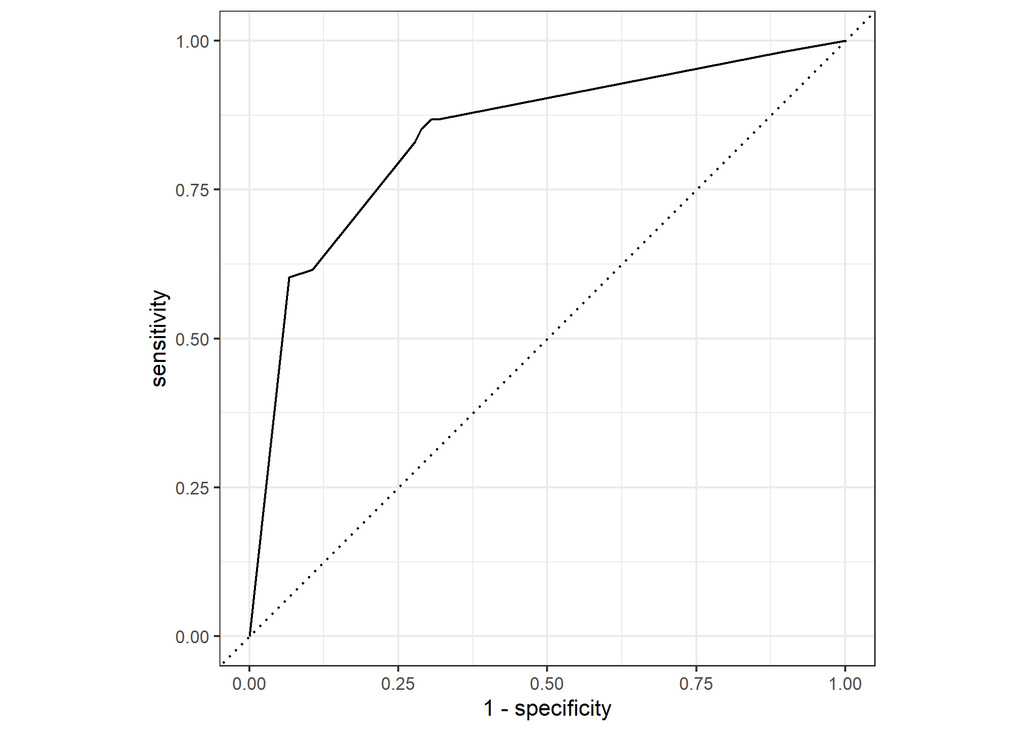

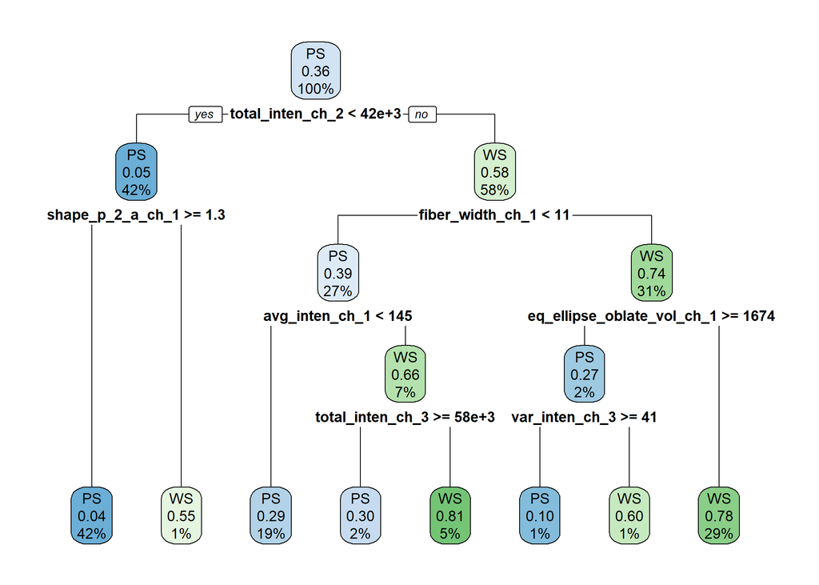

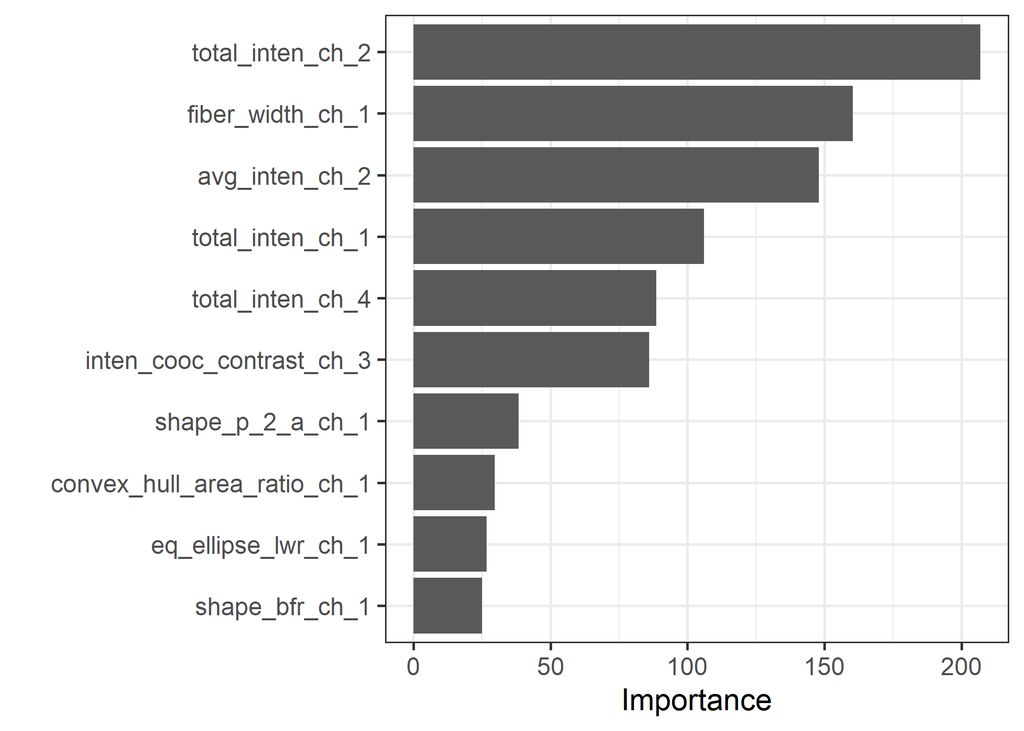

# 20211018 - More {tidymodels} - [{case study - part 1}](https://www.tidymodels.org/start/case-study/)

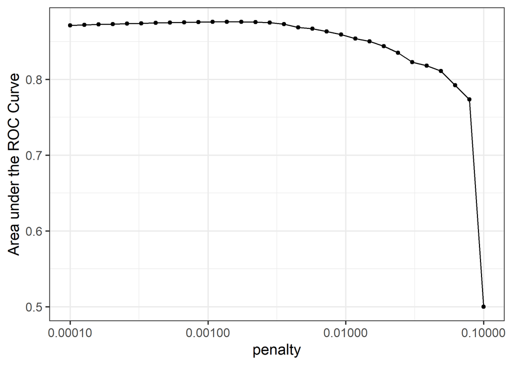

```
## # A tibble: 1 x 7
##   penalty .metric .estimator  mean     n std_err .config
##     <dbl> <chr>   <chr>      <dbl> <int>   <dbl> <chr>
## 1 0.00137 roc_auc binary     0.876     1      NA Preprocessor1_Model12
```

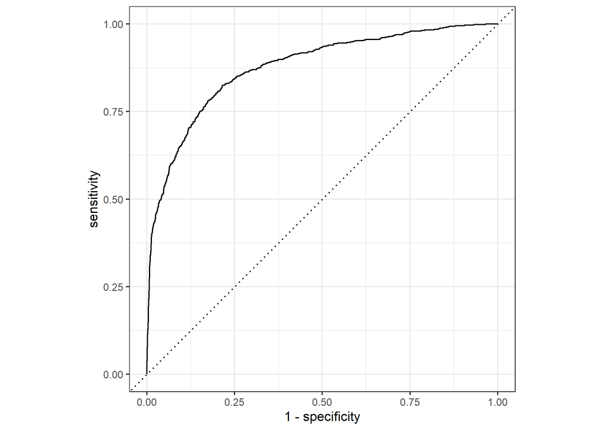

# 20211019 - #TidyTuesday and Pumpkins

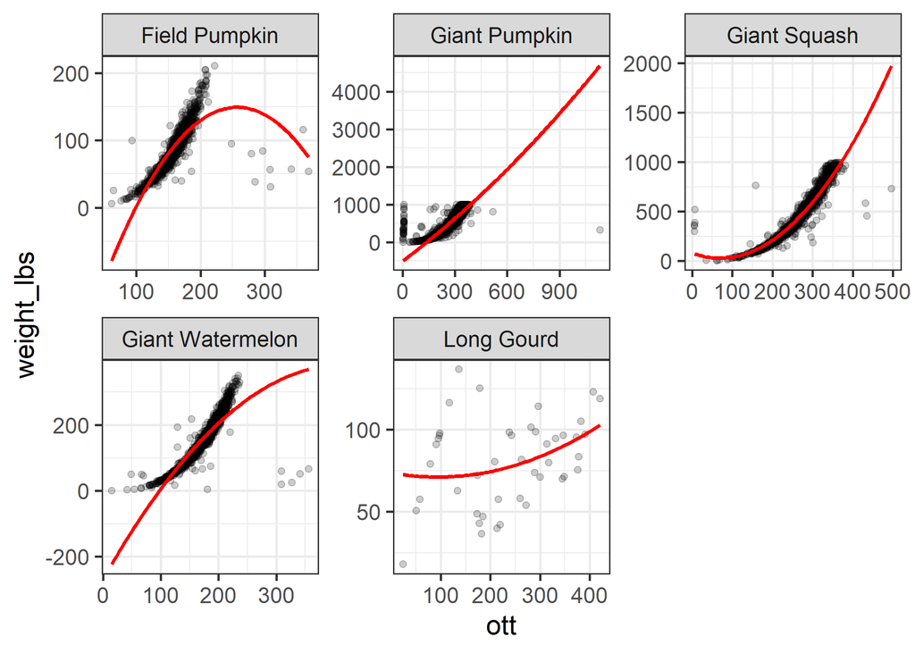

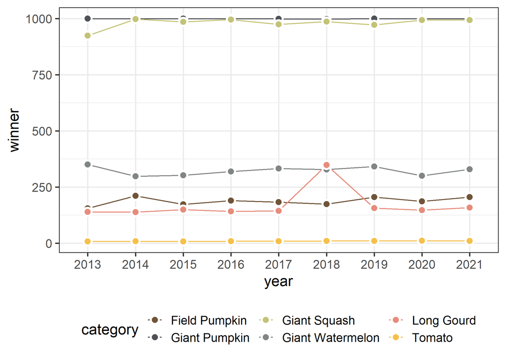

# 20211020 - More {tidymodels} - [{case study - part 2}](https://www.tidymodels.org/start/case-study/)

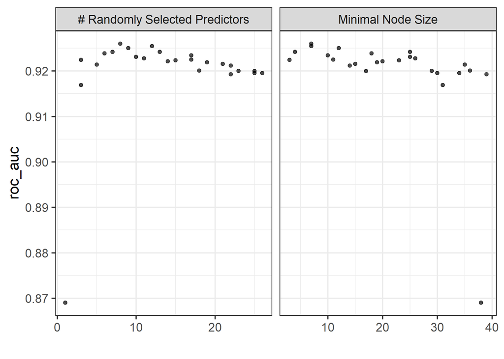

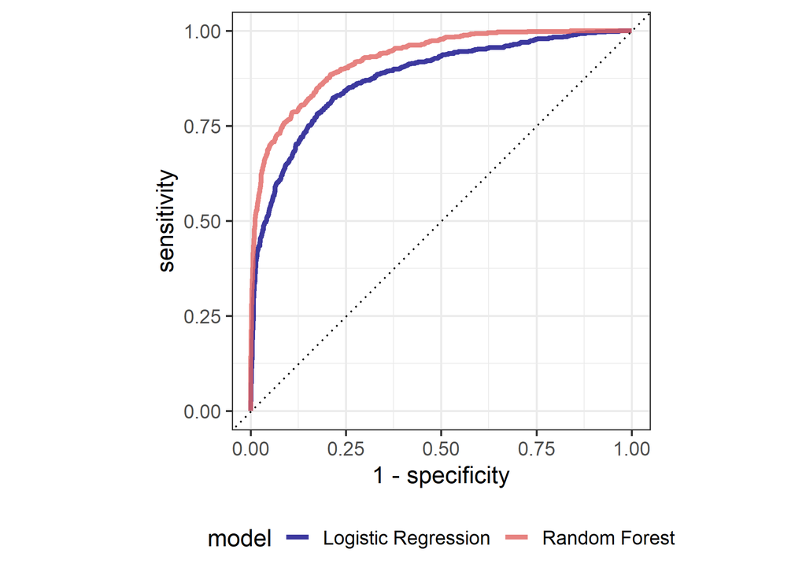

# 20211021 - More {tidymodels} - [{case study - part 3}](https://www.tidymodels.org/start/case-study/)

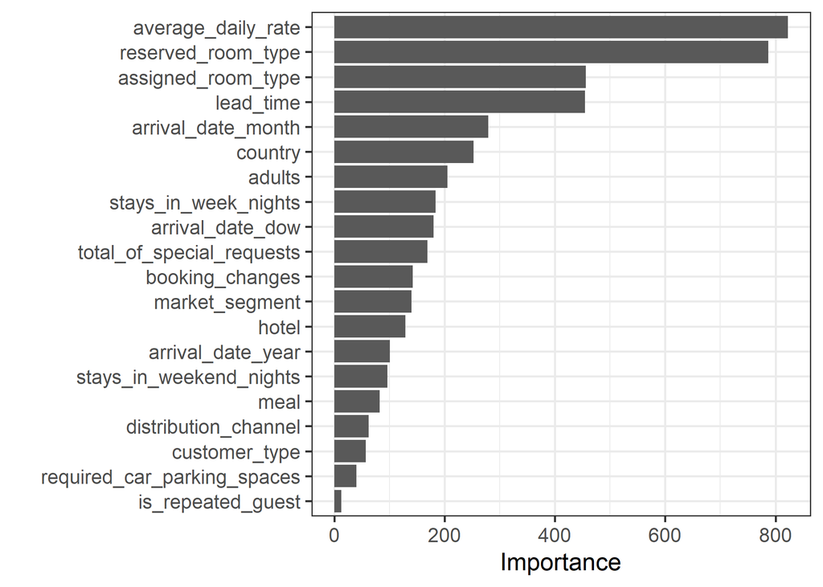

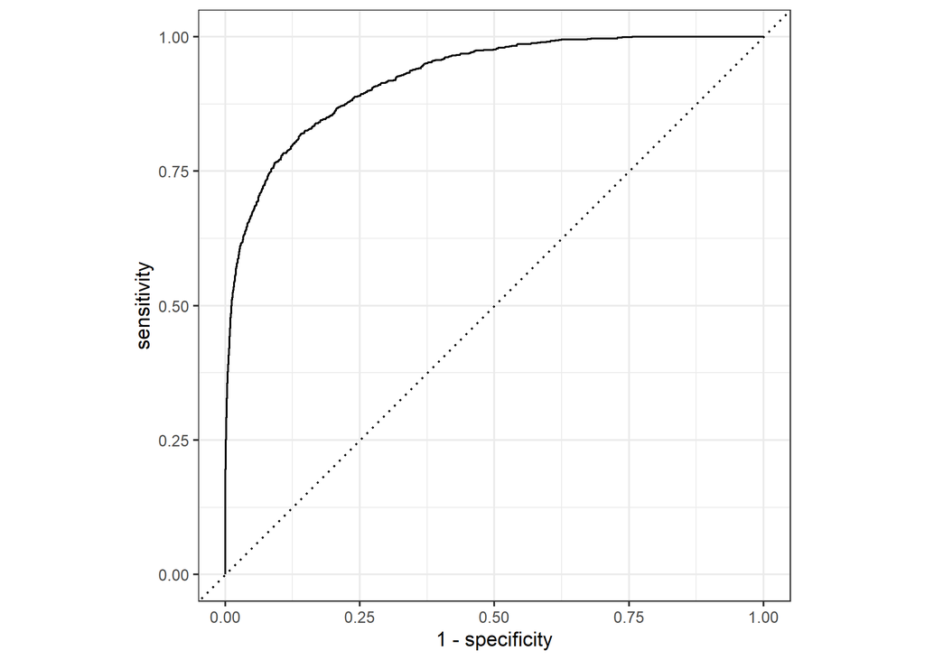

# 20211022 - trying [{biscale}](https://slu-opengis.github.io/biscale/articles/biscale.html)

## V1

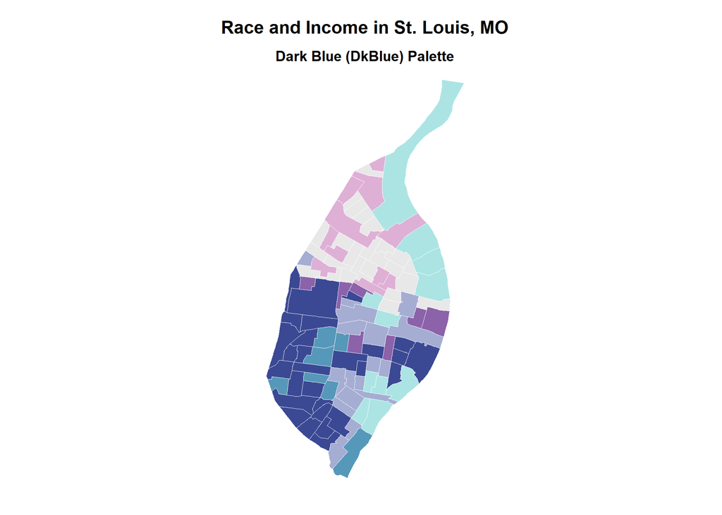

St. Louis - Biscale Map V1

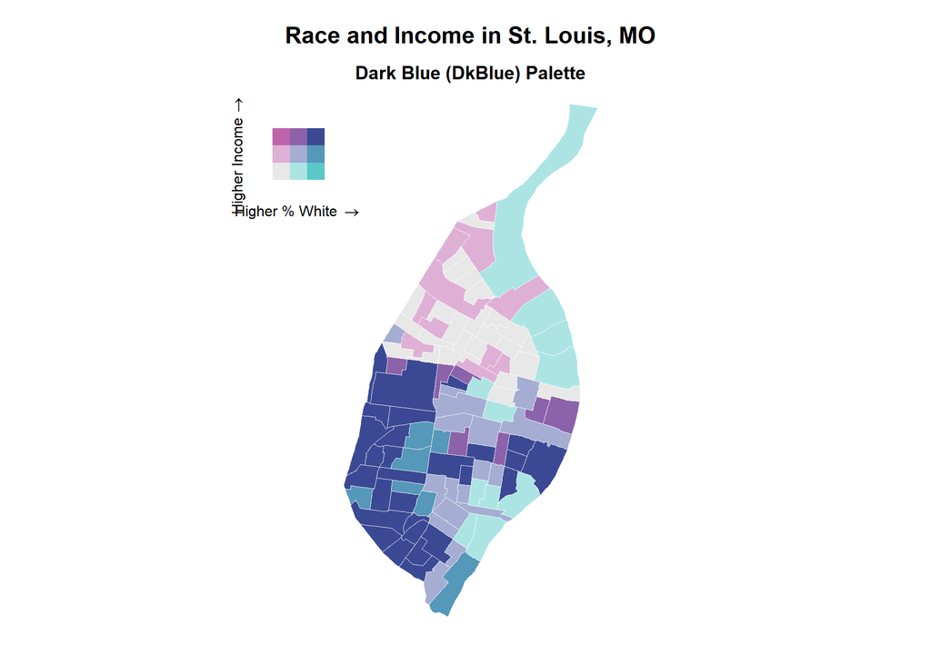

St. Louis - Biscale Map V2

## V2

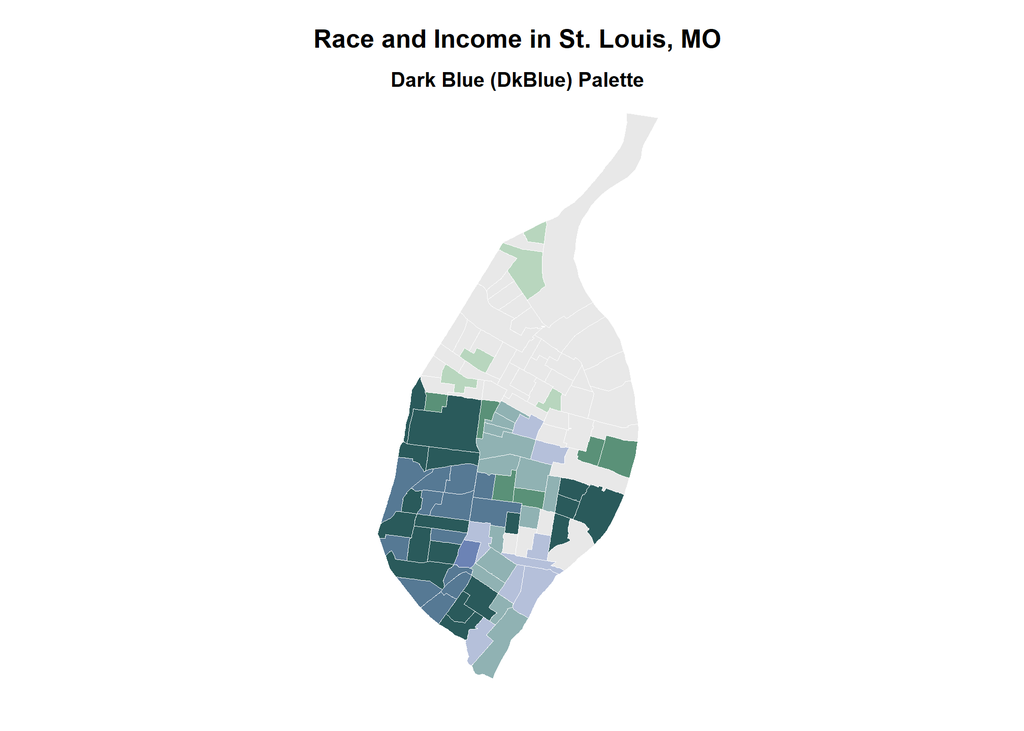

St. Louis - Biscale Map V3

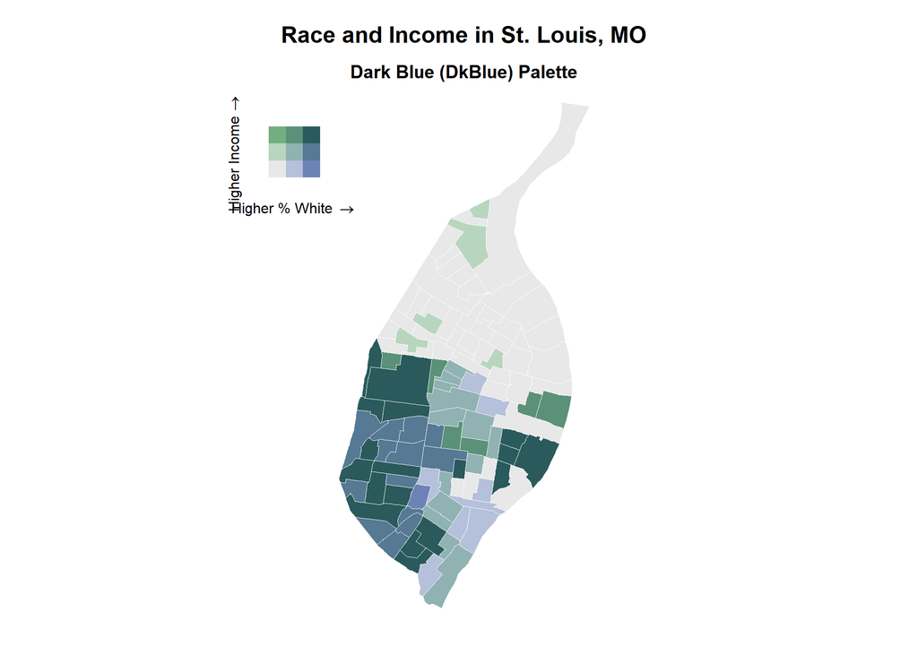

St. Louis - Biscale Map V4

I think this is cool. I’ll be on the lookout for data that I could use in the future.

# 20211025 - trying [{ggdag}](https://cran.r-project.org/web/packages/ggdag/vignettes/intro-to-ggdag.html)

```
## # A DAG with 4 nodes and 17 edges
## #
## # Exposure: x
## # Outcome: y
## #
## # A tibble: 20 x 10
##    set   name      x     y direction to     xend  yend circular path
##    <chr> <chr> <dbl> <dbl> <fct>     <chr> <dbl> <dbl> <lgl>    <chr>
##  1 1     a      14.2  8.02 ->        x      14.1  9.10 FALSE    <NA>
##  2 1     a      14.2  8.02 ->        y      13.3  8.62 FALSE    <NA>
##  3 1     b      13.2  9.71 ->        x      14.1  9.10 FALSE    <NA>
##  4 1     b      13.2  9.71 ->        y      13.3  8.62 FALSE    <NA>
##  5 1     x      14.1  9.10 ->        y      13.3  8.62 FALSE    open path
##  6 1     y      13.3  8.62 <NA>      <NA>   NA   NA    FALSE    open path
##  7 2     a      14.2  8.02 ->        x      14.1  9.10 FALSE    open path
##  8 2     a      14.2  8.02 ->        y      13.3  8.62 FALSE    open path
##  9 2     b      13.2  9.71 ->        x      14.1  9.10 FALSE    <NA>
## 10 2     b      13.2  9.71 ->        y      13.3  8.62 FALSE    <NA>
## 11 2     x      14.1  9.10 ->        y      13.3  8.62 FALSE    <NA>
## 12 2     y      13.3  8.62 <NA>      <NA>   NA   NA    FALSE    open path
## 13 2     x      14.1  9.10 ->        y      13.3  8.62 FALSE    open path
## 14 3     a      14.2  8.02 ->        x      14.1  9.10 FALSE    <NA>
## 15 3     a      14.2  8.02 ->        y      13.3  8.62 FALSE    <NA>
## 16 3     b      13.2  9.71 ->        x      14.1  9.10 FALSE    open path
## 17 3     b      13.2  9.71 ->        y      13.3  8.62 FALSE    open path
## 18 3     x      14.1  9.10 ->        y      13.3  8.62 FALSE    <NA>
## 19 3     y      13.3  8.62 <NA>      <NA>   NA   NA    FALSE    open path
## 20 3     x      14.1  9.10 ->        y      13.3  8.62 FALSE    open path
```

```
## # A tibble: 3 x 2
##   set   n_vars_between
##   <chr>          <dbl>
## 1 1                  1
## 2 2                  3
## 3 3                  3
```

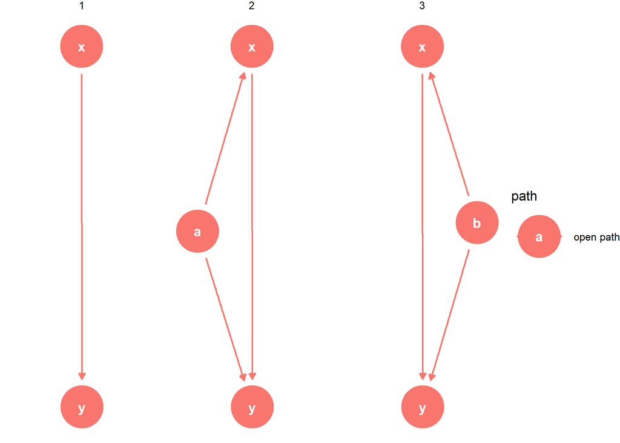

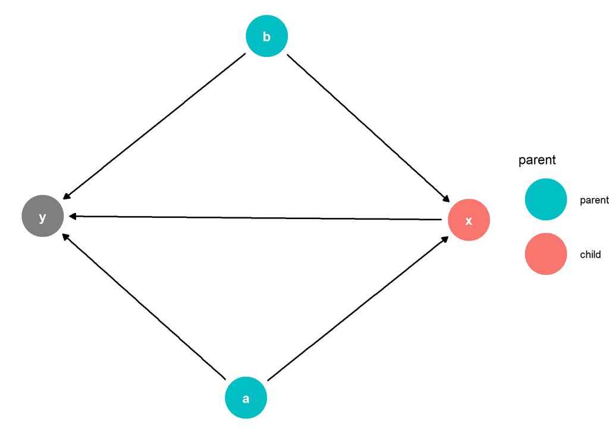

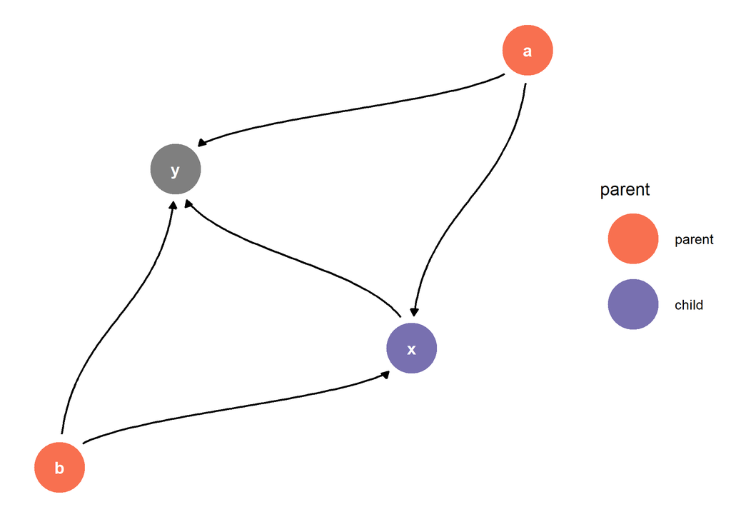

# 20211026 - #TidyTuesday and Trail Running

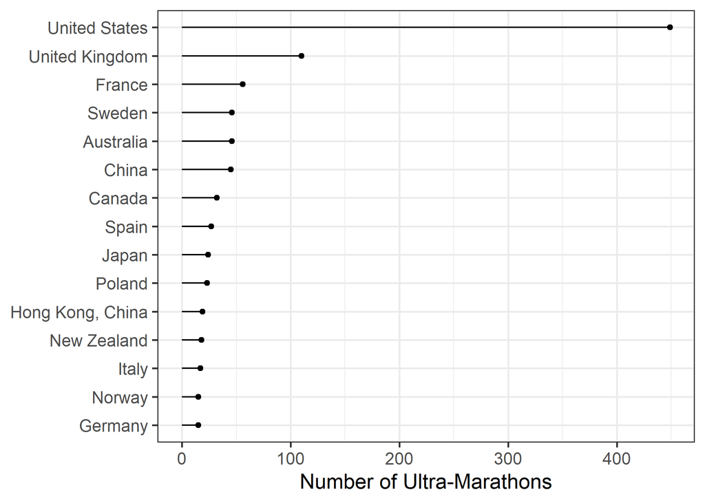

# 20211027 - More #TidyTuesday and Trail Running

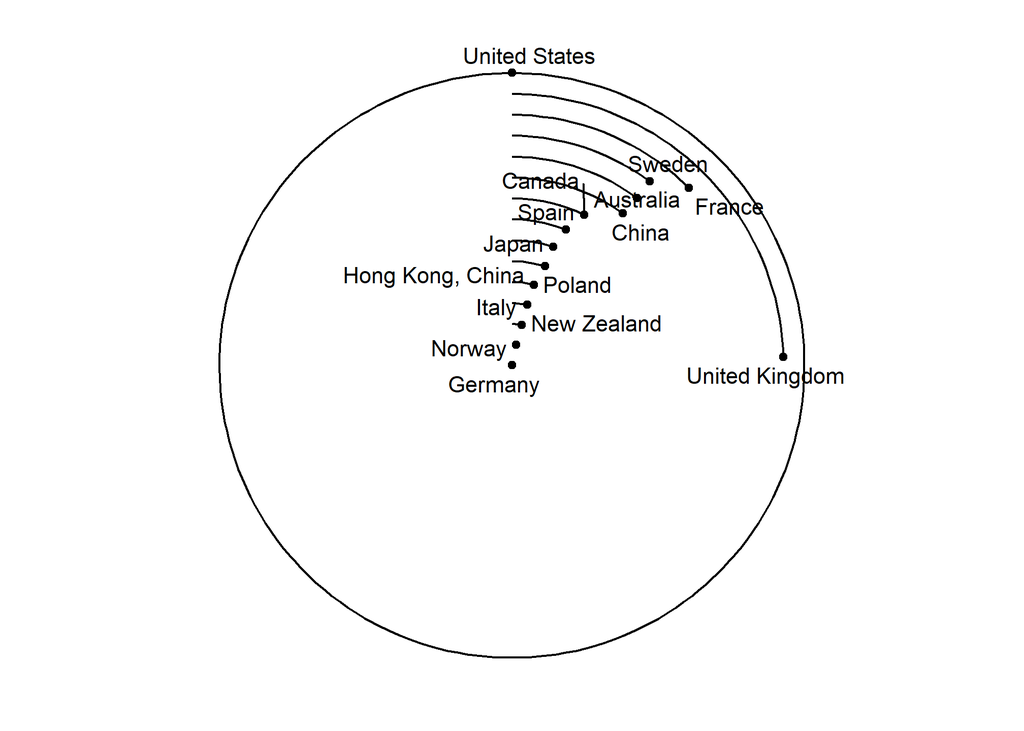

# 20211028 - trying [{labelled}](https://larmarange.github.io/labelled/articles/intro_labelled.html)

This package can be used to label the variables in your dataset. I am thinking about our lab data dictionary as a use.

```r
p_load(labelled)

var_label(iris$Sepal.Length) <- "Length of sepal"

var_label(iris) <- list(Petal.Length = "Length of petal", Petal.Width = "Width of Petal")

var_label(iris$Petal.Width)
```

```
## [1] "Width of Petal"
```

```r
var_label(iris)
```

```
## $Sepal.Length
## [1] "Length of sepal"
##
## $Sepal.Width
## NULL
##
## $Petal.Length
## [1] "Length of petal"
##
## $Petal.Width
## [1] "Width of Petal"
##
## $Species
## NULL
```

```r
var_label(iris$Sepal.Length) <- NULL

View(iris)  # shows labels in viewer under column name

look_for(iris)
```

```
##  pos variable     label           col_type values
##  1   Sepal.Length —               dbl
##  2   Sepal.Width  —               dbl
##  3   Petal.Length Length of petal dbl
##  4   Petal.Width  Width of Petal  dbl
##  5   Species      —               fct      setosa
##                                            versicolor
##                                            virginica
```

```r
v <- labelled(c(1,2,2,2,3,9,1,3,2,NA), c(yes = 1, no = 3, "don't know" = 8, refused = 9))
v
```

```
## <labelled<double>[10]>
##  [1]  1  2  2  2  3  9  1  3  2 NA
##
## Labels:
##  value      label
##      1        yes
##      3         no
##      8 don't know
##      9    refused
```

```r
val_labels(v)
```

```
##        yes         no don't know    refused
##          1          3          8          9
```

```r
val_labels(v) <- NULL
v
```

```
##  [1]  1  2  2  2  3  9  1  3  2 NA
```

```r
val_label(v, 1) <- "yes"
v
```

```
## <labelled<double>[10]>
##  [1]  1  2  2  2  3  9  1  3  2 NA
##
## Labels:
##  value label
##      1   yes
```

# 20211029 - looking into [{codebook}](https://rubenarslan.github.io/codebook/index.html)

Works with {labelled} as well.

# Ideas

template, rprojroot, rgbif, geoviz, ggmap, rayvista, camcorder, {renv}, {rayvertex}, {hrbrthemes}, {firatheme}, {pwr}, voronoi, {reprex}, debug = T for geom_text, {lcmm}, {rolldown}, {ggperiodic}, {codebook}, {muvr}, {pcalg}, {packagemetrics}, {steveproj}, {ungeviz}, {themis}, {biscale}, {prettydoc}, {annotate}, {ggeasy},

https://albert-rapp.de/post/2021-09-16-similar-data-and-list-like-columns/#helpful-concepts

https://www.swisstopo.admin.ch/

https://www.ign.es/web/ign/portal/cbg-area-cartografia

http://shadedrelief.com/SampleElevationModels/

https://www.neonscience.org/resources/learning-hub/tutorials

https://docs.ropensci.org/rgbif/articles/rgbif.html

https://ryo-n7.github.io/2020-05-14-webscrape-soccer-data-with-R/

https://github.com/gkaramanis/aRt/blob/master/split-bar/split-bar.R

https://www.tidymodels.org/

https://rstudio.github.io/distill/basics.html

https://github.com/thebioengineer/camcorder

https://gist.github.com/Worville/c4149ece45a75928a404d316151ba0fe